# Homework 3

Ashleigh Bynum

November 24, 2017

# Section 1 - EDA

Let’s Load our Data and our Libraries in.

Using the Tidyverse Package, I want to explore my raw data. I don’t have any particular correlations that I’m looking for, so I am putting together plots just to see any interesting patterns:

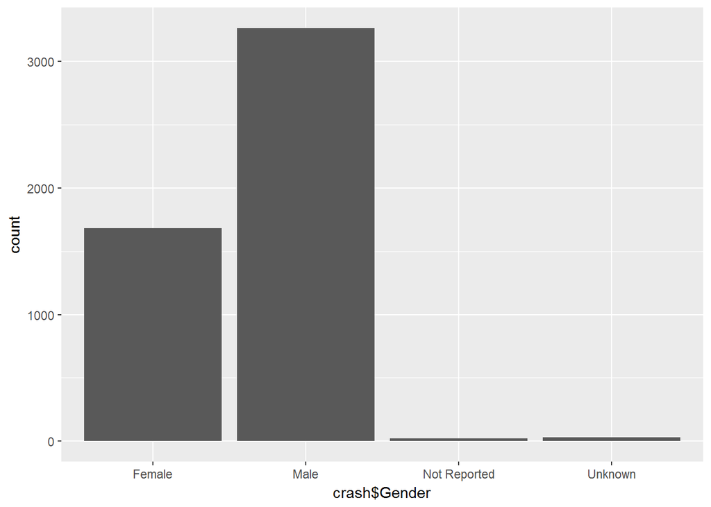

```r
# Bar graph of Genders in our dataset
ggplot(data = crash) + geom_bar(aes(crash$Gender))
```

The Genders Plot reveals that there are twice as many males in this dataset as there are females. Lets dig into this furhter:

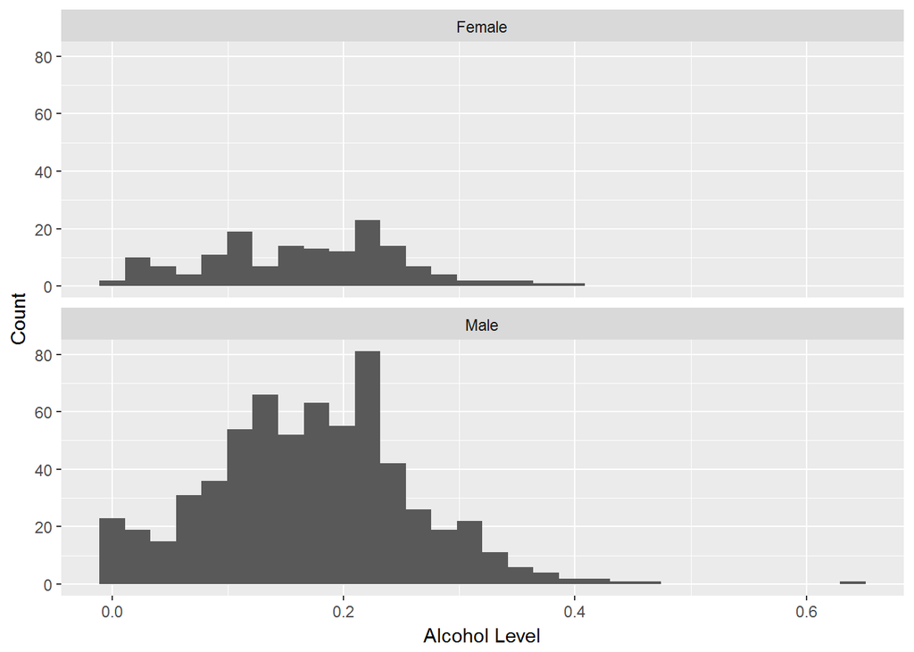

```r
# separate alcohol vs. non-alcohol crashes
crashalcohol = crash %>% filter(crash$Alcohol.Results > 0)
crashnoalcohol = crash %>% filter(crash$Alcohol.Results == 0)


# Histogram of Make to female blood alcohol level
ggplot(data = crashalcohol) + geom_histogram(mapping = aes(x = crashalcohol$Alcohol.Results)) +
    facet_wrap(~crashalcohol$Gender, nrow = 2) + xlab("Alcohol Level") + ylab("Count")
```

Plotting gender against blood alcohol content shows that Males from this dataset were involved in more instances of fatal crashes involving alcohol at a higher blood alcohol content than females.

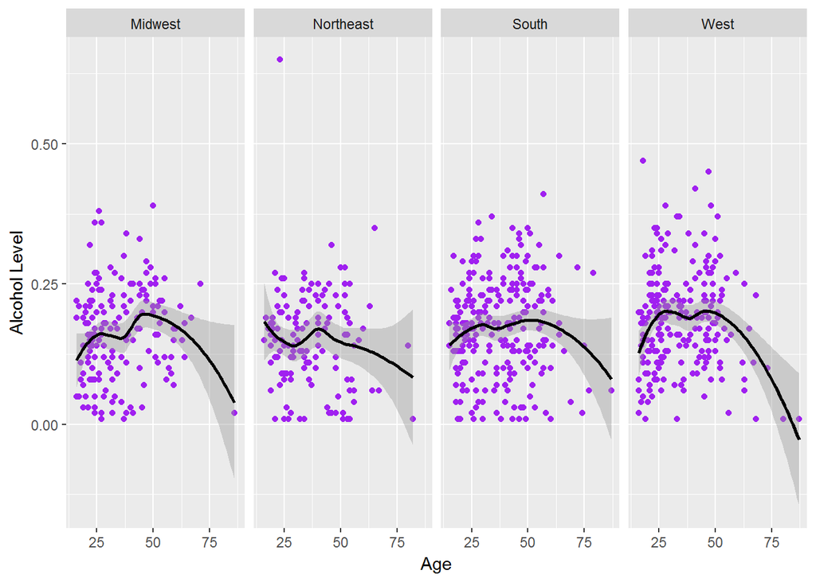

```r
# Plotting Age vs. Alcohol Levels
ggplot(data = crashalcohol) + geom_point(mapping = aes(y = crashalcohol$Alcohol.Results,
    x = crashalcohol$Age), color = "Purple") + geom_smooth(mapping = aes(y = crashalcohol$Alcohol.Results,
    x = crashalcohol$Age), color = "Black") + xlab("Age") + ylab("Alcohol Level") +
    facet_grid(. ~ Region) + scale_x_continuous("Age") + scale_y_continuous("Alcohol Level")
```

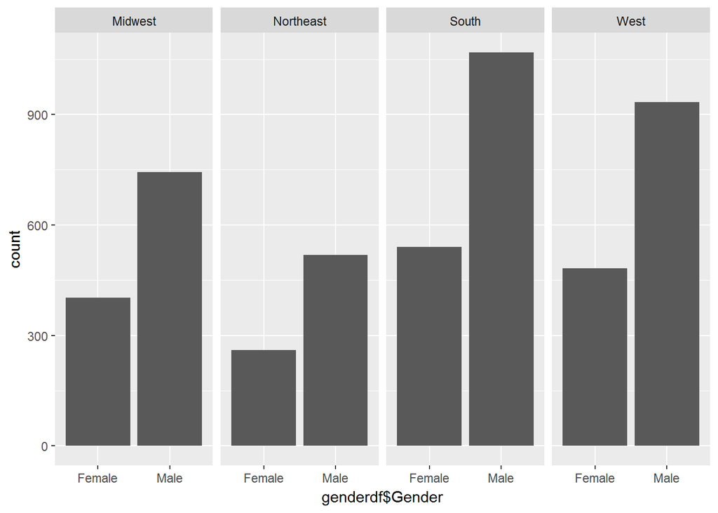

```r
# Gender to Region
genderdf = crash %>% filter(crash$Gender == "Female" | crash$Gender == "Male")

ggplot(data = genderdf) + geom_bar(mapping = aes(x = genderdf$Gender)) + facet_grid(. ~
    Region)
```

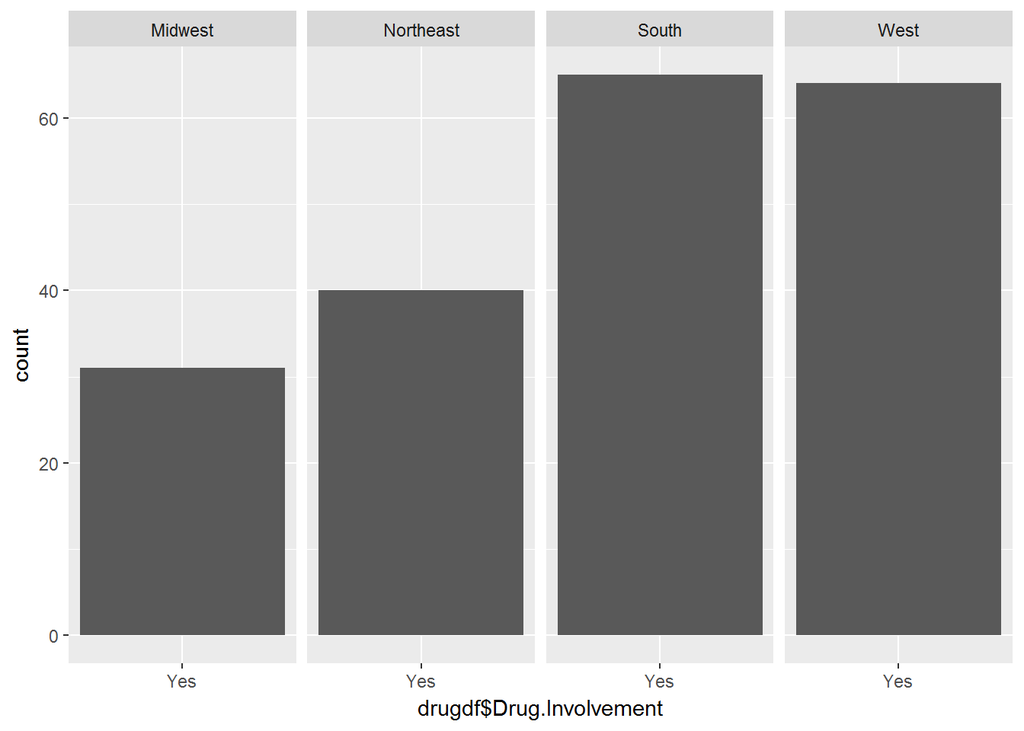

```r
# Drug involvement by State


drugdf = crash %>% filter(crash$Drug.Involvement == "Yes")

ggplot(data = drugdf) + geom_bar(mapping = aes(x = drugdf$Drug.Involvement)) +
    facet_grid(. ~ Region)
```

# Section 2 - Clustering

The KProto function in the clustMixType package requires the data to be of either factor or numeric type. We will convert the variables.

How many groups should we decide on? I will use the elbow method to help determine the optimal number of clusters.

```r
# Elbow Method for finding the optimal number of clusters
set.seed(123)
# Compute and plot wss for k = 2 to k = 15.


myData <- crash_clean
myData = as.data.frame(myData)

wss = (nrow(myData) - 1) * sum(apply(myData, 2, var))
for (i in 2:15) wss[i] <- sum(kproto(myData, i)$withinss)
```

[output not shown]

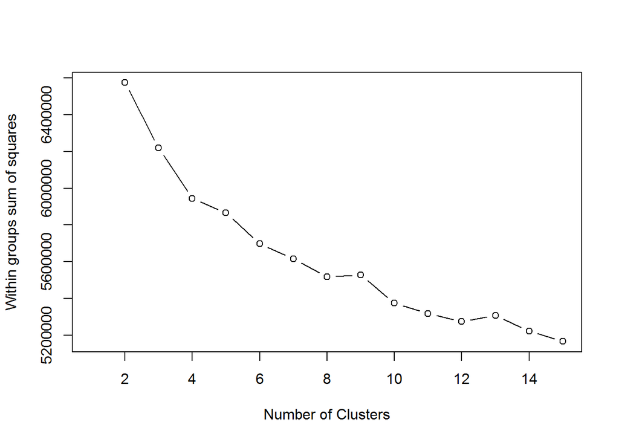

```r
# Plot Elbow
plot(1:15, wss, type = "b", xlab = "Number of Clusters", ylab = "Within groups sum of squares")
```

Using the formula to create the elbow plot, we see that the first major bend is around cluster 4. This can be a good starting point for us.

```r
# K=4 Clusters
set.seed(2345)
k4 = kproto(crash_clean, k = 4, nstart = 25)
```

```
## Estimated lambda: 157.2697
```

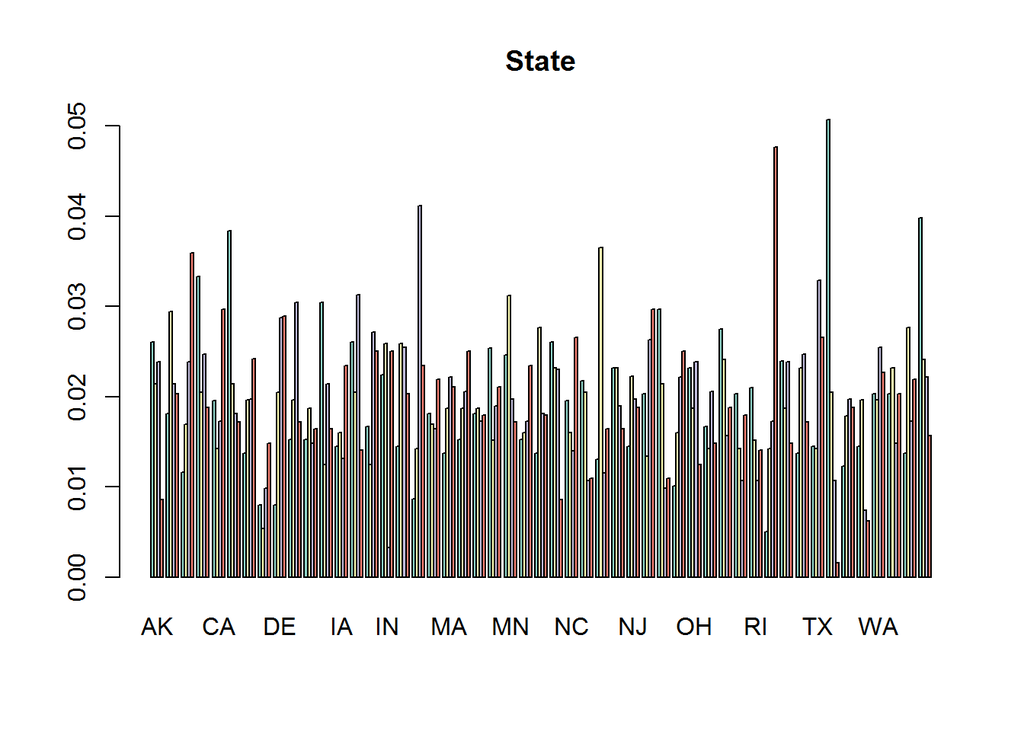

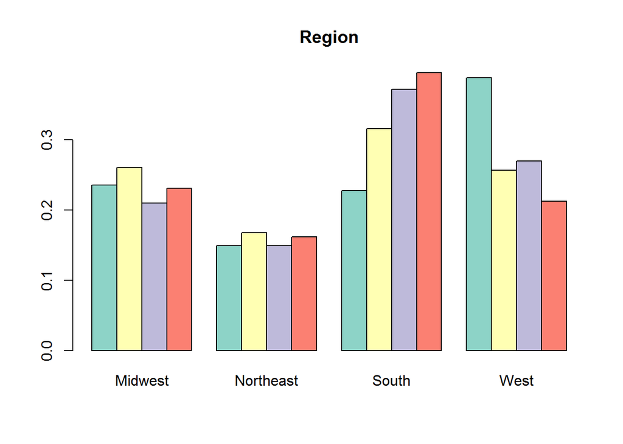

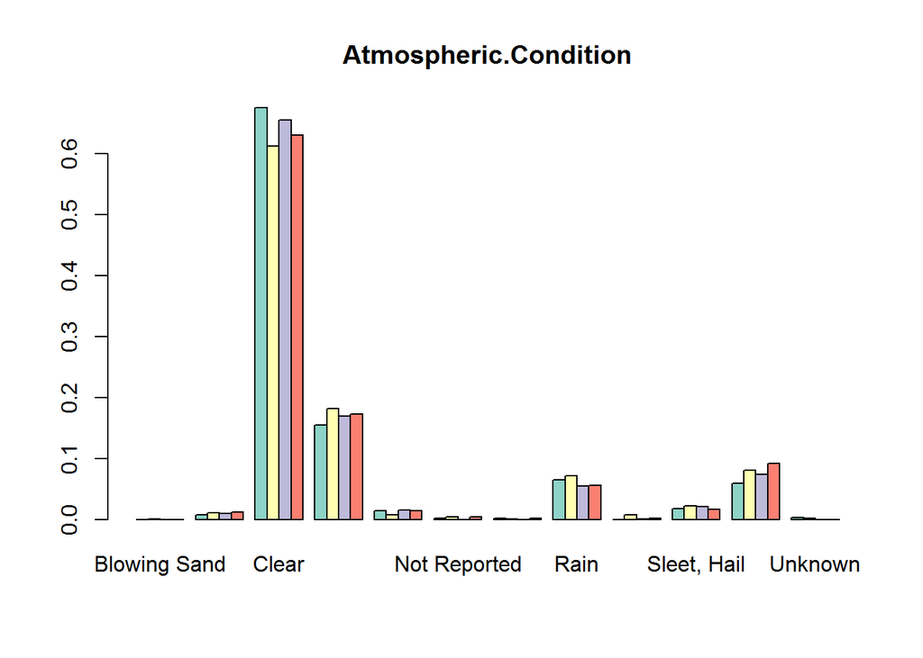

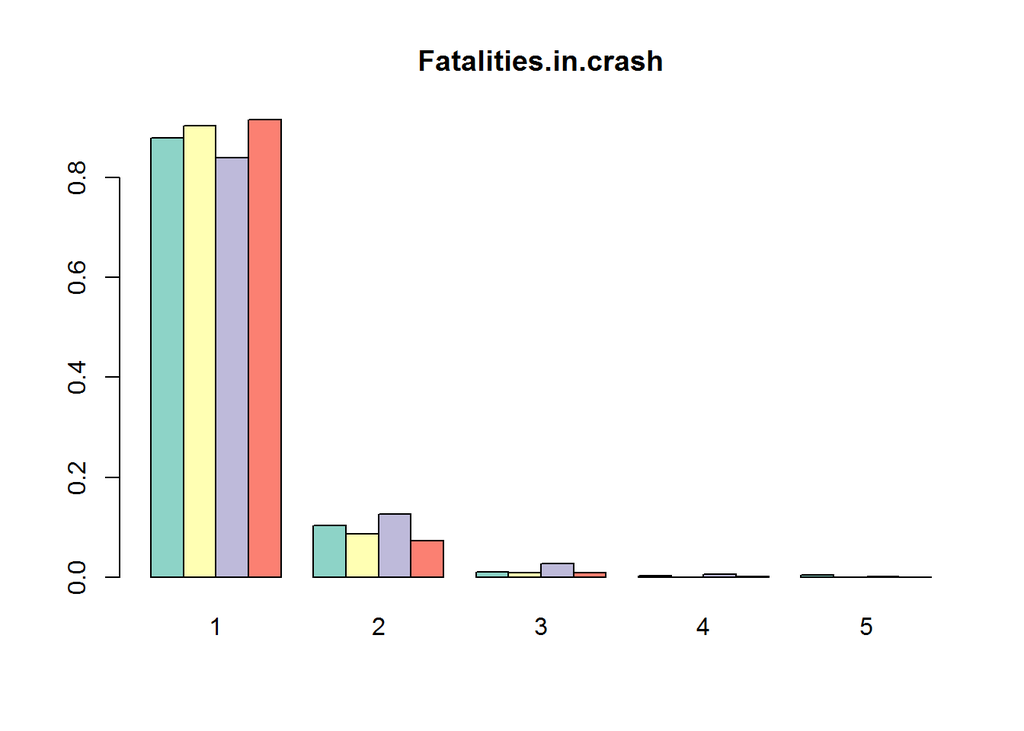

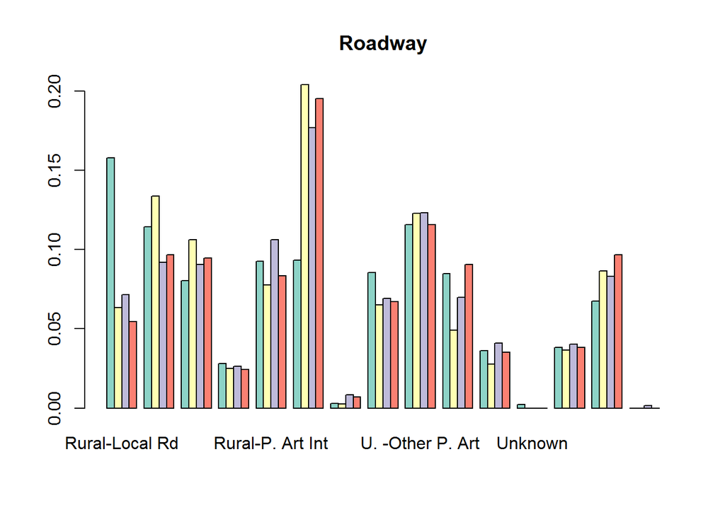

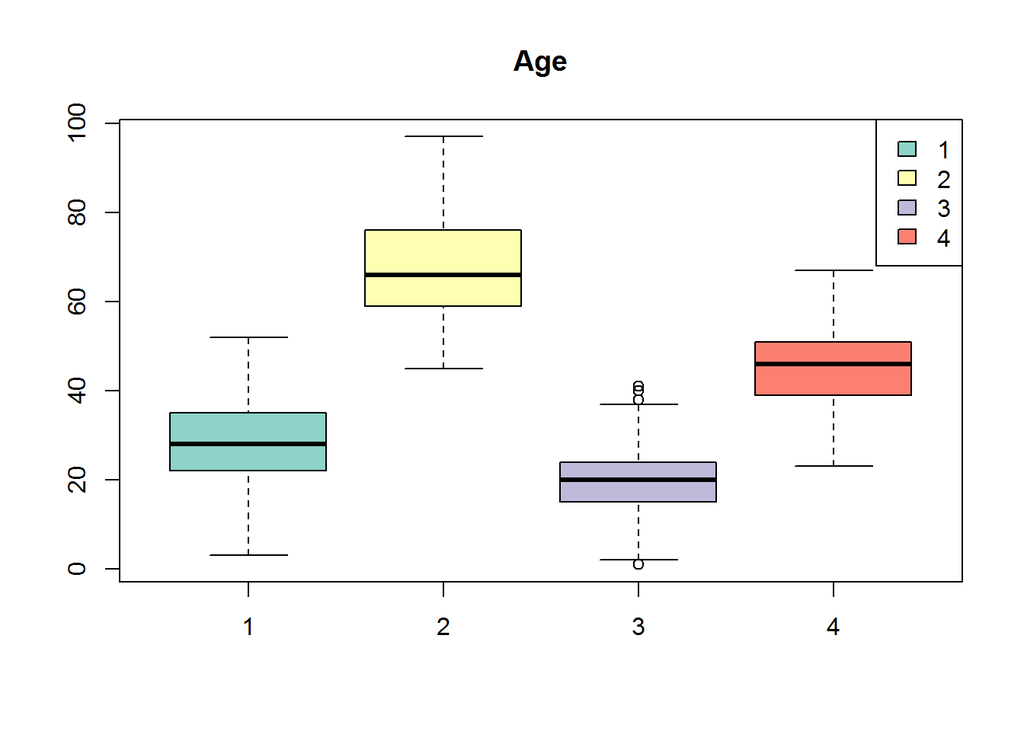

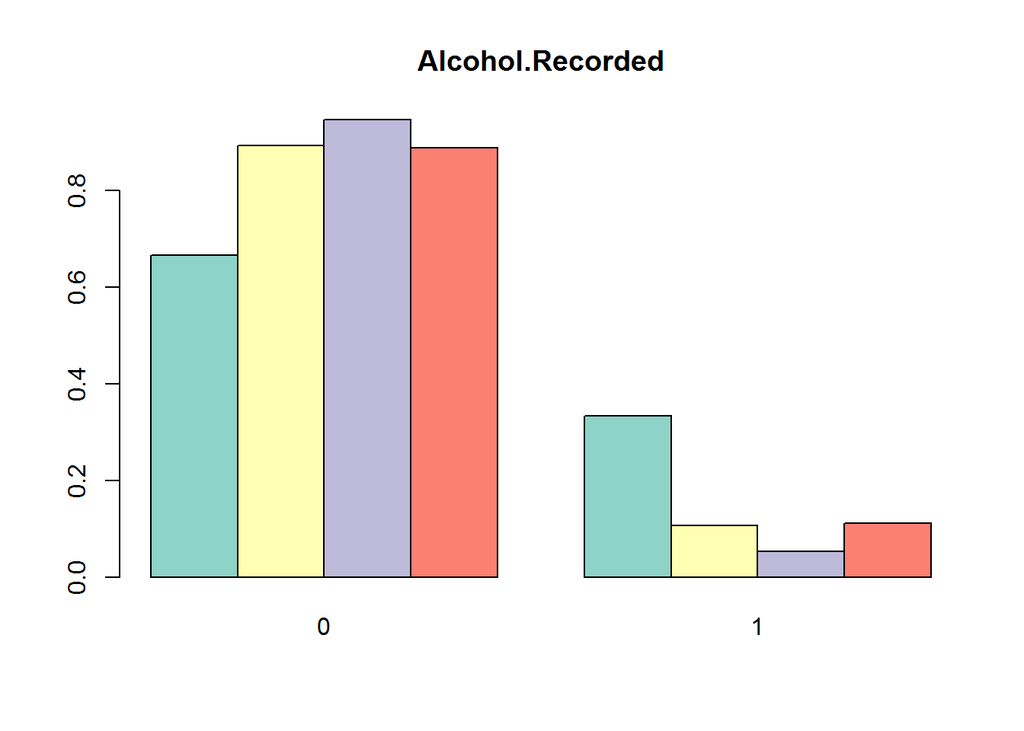

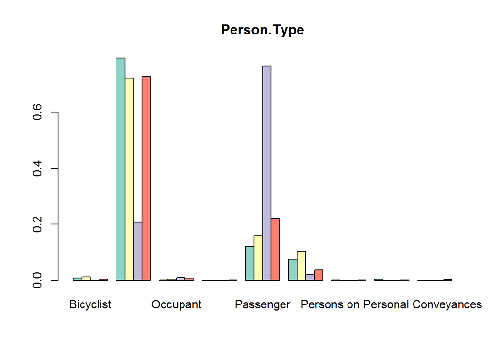

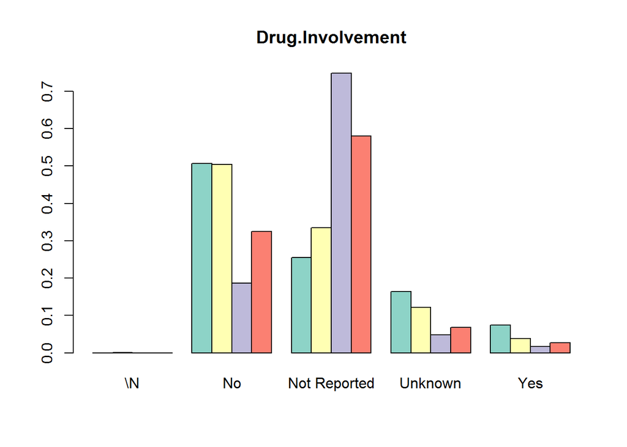

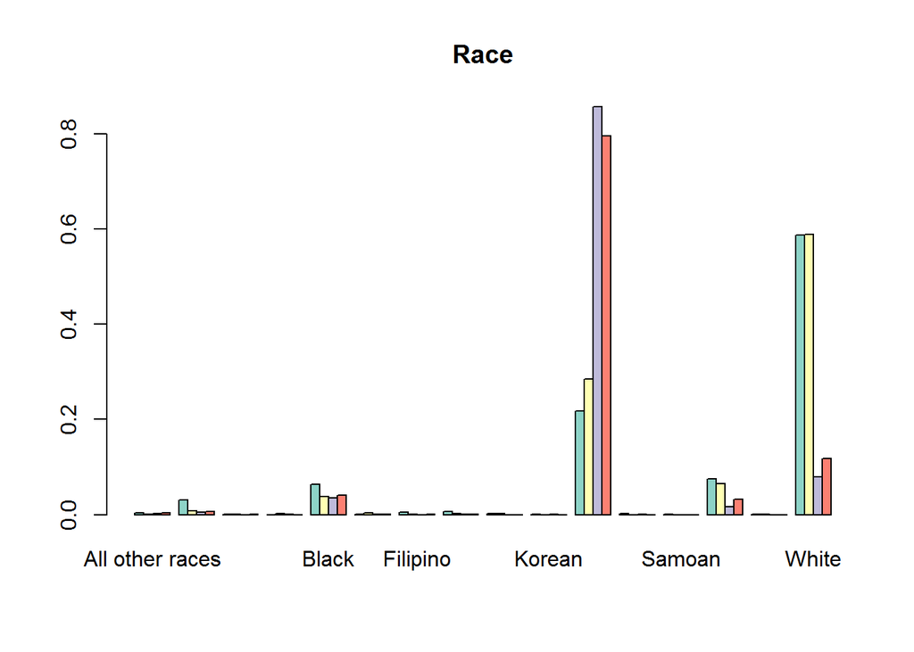

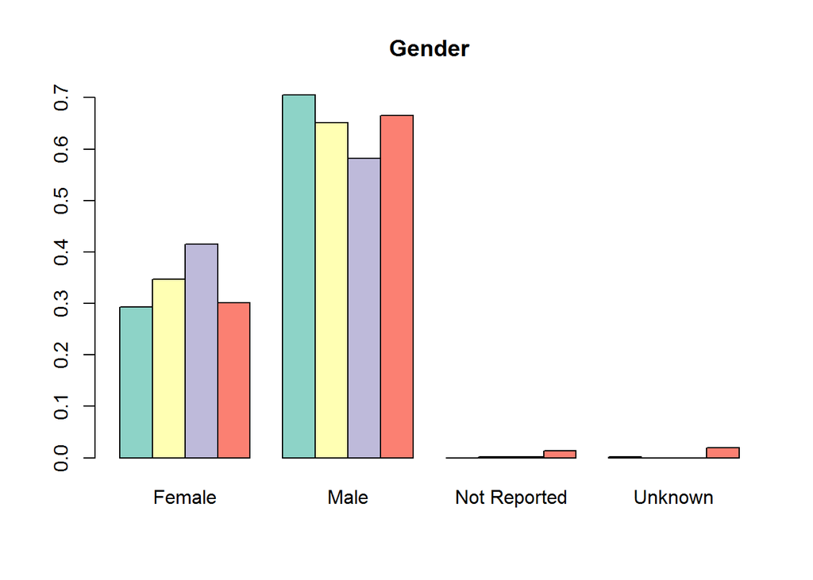

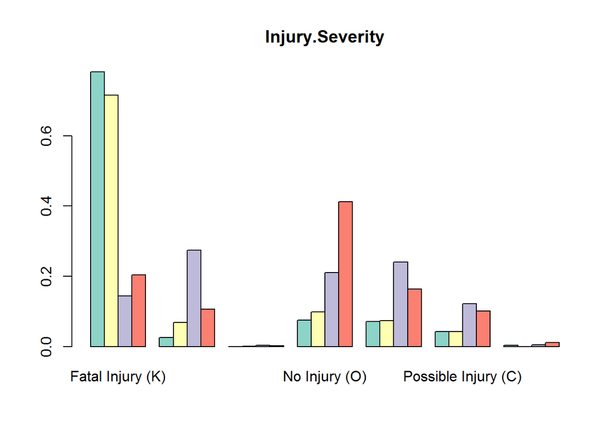

[6 more figures not shown]

```r
clprofiles(k4, crash_clean, vars = NULL)
```

The clprofiles plots shows use the profiles of the different clusters. We can start seeing the differences in our clusters. It’s worth exploring if adding more clusters creates another dissimilar group.